# Risk Factor Analysis

## Outcome Variable

**Outcome Variable:** whz

## Predictor Variables

**Intervention Variable:** nrooms

**Adjustment Set:**

unadjusted

## Stratifying Variables

The analysis was stratified on these variable(s):

- agecat
- studyid
- country

## Data Summary

| agecat | studyid | country | nrooms | n_cell | n |
| --- | --- | --- | --- | --- | --- |
| Birth | ki0047075b-MAL-ED | BANGLADESH | 4+ | 12 | 201 |
| Birth | ki0047075b-MAL-ED | BANGLADESH | 1 | 121 | 201 |
| Birth | ki0047075b-MAL-ED | BANGLADESH | 2 | 43 | 201 |
| Birth | ki0047075b-MAL-ED | BANGLADESH | 3 | 25 | 201 |
| Birth | ki0047075b-MAL-ED | BRAZIL | 4+ | 29 | 57 |
| Birth | ki0047075b-MAL-ED | BRAZIL | 1 | 0 | 57 |
| Birth | ki0047075b-MAL-ED | BRAZIL | 2 | 10 | 57 |
| Birth | ki0047075b-MAL-ED | BRAZIL | 3 | 18 | 57 |
| Birth | ki0047075b-MAL-ED | INDIA | 4+ | 2 | 39 |
| Birth | ki0047075b-MAL-ED | INDIA | 1 | 17 | 39 |
| Birth | ki0047075b-MAL-ED | INDIA | 2 | 16 | 39 |
| Birth | ki0047075b-MAL-ED | INDIA | 3 | 4 | 39 |
| Birth | ki0047075b-MAL-ED | NEPAL | 4+ | 15 | 25 |
| Birth | ki0047075b-MAL-ED | NEPAL | 1 | 6 | 25 |
| Birth | ki0047075b-MAL-ED | NEPAL | 2 | 2 | 25 |
| Birth | ki0047075b-MAL-ED | NEPAL | 3 | 2 | 25 |
| Birth | ki0047075b-MAL-ED | PERU | 4+ | 103 | 210 |
| Birth | ki0047075b-MAL-ED | PERU | 1 | 13 | 210 |
| Birth | ki0047075b-MAL-ED | PERU | 2 | 45 | 210 |
| Birth | ki0047075b-MAL-ED | PERU | 3 | 49 | 210 |
| Birth | ki0047075b-MAL-ED | SOUTH AFRICA | 4+ | 66 | 95 |
| Birth | ki0047075b-MAL-ED | SOUTH AFRICA | 1 | 5 | 95 |
| Birth | ki0047075b-MAL-ED | SOUTH AFRICA | 2 | 12 | 95 |
| Birth | ki0047075b-MAL-ED | SOUTH AFRICA | 3 | 12 | 95 |
| Birth | ki0047075b-MAL-ED | TANZANIA, UNITED REPUBLIC OF | 4+ | 45 | 112 |
| Birth | ki0047075b-MAL-ED | TANZANIA, UNITED REPUBLIC OF | 1 | 9 | 112 |
| Birth | ki0047075b-MAL-ED | TANZANIA, UNITED REPUBLIC OF | 2 | 28 | 112 |
| Birth | ki0047075b-MAL-ED | TANZANIA, UNITED REPUBLIC OF | 3 | 30 | 112 |
| Birth | ki1000108-CMC-V-BCS-2002 | INDIA | 4+ | 5 | 86 |
| Birth | ki1000108-CMC-V-BCS-2002 | INDIA | 1 | 35 | 86 |

[output cut: 162 more lines]

The following strata were considered:

- agecat: 24 months, studyid: ki0047075b-MAL-ED, country: BANGLADESH
- agecat: 24 months, studyid: ki0047075b-MAL-ED, country: BRAZIL
- agecat: 24 months, studyid: ki0047075b-MAL-ED, country: INDIA
- agecat: 24 months, studyid: ki0047075b-MAL-ED, country: NEPAL
- agecat: 24 months, studyid: ki0047075b-MAL-ED, country: PERU
- agecat: 24 months, studyid: ki0047075b-MAL-ED, country: SOUTH AFRICA
- agecat: 24 months, studyid: ki0047075b-MAL-ED, country: TANZANIA, UNITED REPUBLIC OF
- agecat: 24 months, studyid: ki1000108-CMC-V-BCS-2002, country: INDIA
- agecat: 24 months, studyid: ki1000108-IRC, country: INDIA
- agecat: 24 months, studyid: ki1017093b-PROVIDE, country: BANGLADESH
- agecat: 24 months, studyid: ki1017093c-NIH-Crypto, country: BANGLADESH
- agecat: 24 months, studyid: ki1113344-GMS-Nepal, country: NEPAL
- agecat: 24 months, studyid: ki1114097-CONTENT, country: PERU
- agecat: 24 months, studyid: ki1135781-COHORTS, country: INDIA
- agecat: 24 months, studyid: kiGH5241-JiVitA-3, country: BANGLADESH
- agecat: 24 months, studyid: kiGH5241-JiVitA-4, country: BANGLADESH
- agecat: 6 months, studyid: ki0047075b-MAL-ED, country: BANGLADESH
- agecat: 6 months, studyid: ki0047075b-MAL-ED, country: BRAZIL
- agecat: 6 months, studyid: ki0047075b-MAL-ED, country: INDIA
- agecat: 6 months, studyid: ki0047075b-MAL-ED, country: NEPAL
- agecat: 6 months, studyid: ki0047075b-MAL-ED, country: PERU
- agecat: 6 months, studyid: ki0047075b-MAL-ED, country: SOUTH AFRICA
- agecat: 6 months, studyid: ki0047075b-MAL-ED, country: TANZANIA, UNITED REPUBLIC OF
- agecat: 6 months, studyid: ki1000108-CMC-V-BCS-2002, country: INDIA
- agecat: 6 months, studyid: ki1000108-IRC, country: INDIA
- agecat: 6 months, studyid: ki1017093b-PROVIDE, country: BANGLADESH
- agecat: 6 months, studyid: ki1017093c-NIH-Crypto, country: BANGLADESH
- agecat: 6 months, studyid: ki1113344-GMS-Nepal, country: NEPAL
- agecat: 6 months, studyid: ki1114097-CONTENT, country: PERU
- agecat: 6 months, studyid: ki1135781-COHORTS, country: INDIA
- agecat: 6 months, studyid: kiGH5241-JiVitA-3, country: BANGLADESH
- agecat: 6 months, studyid: kiGH5241-JiVitA-4, country: BANGLADESH
- agecat: Birth, studyid: ki0047075b-MAL-ED, country: BANGLADESH
- agecat: Birth, studyid: ki0047075b-MAL-ED, country: BRAZIL
- agecat: Birth, studyid: ki0047075b-MAL-ED, country: INDIA
- agecat: Birth, studyid: ki0047075b-MAL-ED, country: NEPAL
- agecat: Birth, studyid: ki0047075b-MAL-ED, country: PERU
- agecat: Birth, studyid: ki0047075b-MAL-ED, country: SOUTH AFRICA
- agecat: Birth, studyid: ki0047075b-MAL-ED, country: TANZANIA, UNITED REPUBLIC OF
- agecat: Birth, studyid: ki1000108-CMC-V-BCS-2002, country: INDIA
- agecat: Birth, studyid: ki1000108-IRC, country: INDIA
- agecat: Birth, studyid: ki1017093b-PROVIDE, country: BANGLADESH
- agecat: Birth, studyid: ki1017093c-NIH-Crypto, country: BANGLADESH
- agecat: Birth, studyid: ki1113344-GMS-Nepal, country: NEPAL
- agecat: Birth, studyid: ki1114097-CONTENT, country: PERU
- agecat: Birth, studyid: ki1135781-COHORTS, country: INDIA
- agecat: Birth, studyid: kiGH5241-JiVitA-3, country: BANGLADESH
- agecat: Birth, studyid: kiGH5241-JiVitA-4, country: BANGLADESH

### Dropped Strata

Some strata were dropped due to rare outcomes:

- agecat: Birth, studyid: ki0047075b-MAL-ED, country: BRAZIL
- agecat: Birth, studyid: ki0047075b-MAL-ED, country: INDIA
- agecat: Birth, studyid: ki0047075b-MAL-ED, country: NEPAL
- agecat: Birth, studyid: ki1114097-CONTENT, country: PERU
- agecat: 6 months, studyid: ki0047075b-MAL-ED, country: BRAZIL
- agecat: 24 months, studyid: ki0047075b-MAL-ED, country: BRAZIL

## Methods Detail

We’re interested in the causal parameters $E[Y_a]$ for all values of $a \in \mathcal{A}$. These parameters represent the mean outcome if, possibly contrary to fact, we intervened to set all units to have $A=a$. Under the randomization and positivity assumptions, these are identified by the statistical parameters $\psi_a=E_W[E_{Y|A,W}(Y|A=a,W)]$. In addition, we’re interested in the mean of $Y$, $E[Y]$ under no intervention (the observed mean). We will estimate these parameters by using SuperLearner to fit the relevant likelihood factors – $E_{Y|A,W}(Y|A=a,W)$ and $p(A=a|W)$, and then updating our likelihood fit using a joint TMLE.

For unadjusted analyses ($W=\{\}$), initial likelihoods were estimated using Lrnr_glm to estimate the simple $E(Y|A)$ and Lrnr_mean to estimate $p(A)$. For adjusted analyses, a small library containing Lrnr_glmnet, Lrnr_xgboost, and Lrnr_mean was used.

Having estimated these parameters, we will then use the delta method to estimate relative risks and attributable risks relative to a prespecified baseline level of $A$.

# Results Detail

## Results Plots

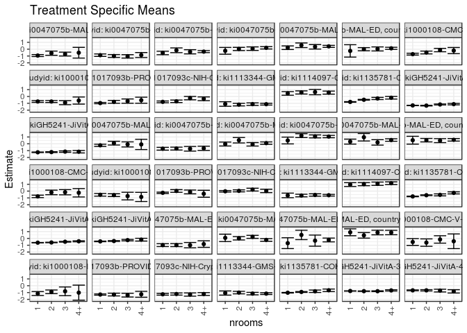

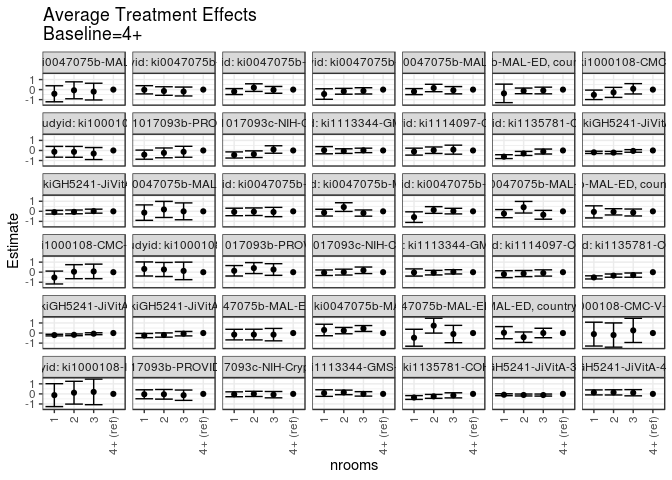

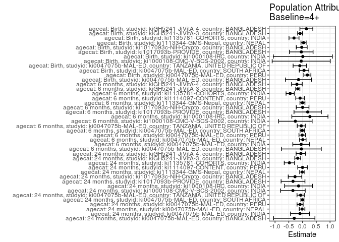

## Results Table

### Parameter: TSM

| agecat | studyid | country | intervention_level | baseline_level | estimate | ci_lower | ci_upper |
| --- | --- | --- | --- | --- | --- | --- | --- |
| Birth | ki0047075b-MAL-ED | BANGLADESH | 4+ | NA | -0.8266667 | -1.3087655 | -0.3445679 |
| Birth | ki0047075b-MAL-ED | BANGLADESH | 1 | NA | -0.9826860 | -1.1974239 | -0.7679480 |
| Birth | ki0047075b-MAL-ED | BANGLADESH | 2 | NA | -0.9779070 | -1.2017073 | -0.7541067 |
| Birth | ki0047075b-MAL-ED | BANGLADESH | 3 | NA | -0.9866000 | -1.3724535 | -0.6007465 |
| Birth | ki0047075b-MAL-ED | PERU | 4+ | NA | -0.2219417 | -0.4143783 | -0.0295052 |
| Birth | ki0047075b-MAL-ED | PERU | 1 | NA | 0.0830769 | -0.4559833 | 0.6221372 |
| Birth | ki0047075b-MAL-ED | PERU | 2 | NA | 0.0182222 | -0.2293624 | 0.2658069 |
| Birth | ki0047075b-MAL-ED | PERU | 3 | NA | 0.2271429 | 0.0054463 | 0.4488394 |
| Birth | ki0047075b-MAL-ED | SOUTH AFRICA | 4+ | NA | -0.2287879 | -0.5065288 | 0.0489530 |
| Birth | ki0047075b-MAL-ED | SOUTH AFRICA | 1 | NA | -0.6960000 | -1.4913352 | 0.0993352 |
| Birth | ki0047075b-MAL-ED | SOUTH AFRICA | 2 | NA | 0.5066667 | -0.1807332 | 1.1940665 |
| Birth | ki0047075b-MAL-ED | SOUTH AFRICA | 3 | NA | -0.3275000 | -1.1444022 | 0.4894022 |
| Birth | ki0047075b-MAL-ED | TANZANIA, UNITED REPUBLIC OF | 4+ | NA | 0.8631111 | 0.5363093 | 1.1899130 |
| Birth | ki0047075b-MAL-ED | TANZANIA, UNITED REPUBLIC OF | 1 | NA | 0.9000000 | 0.3934379 | 1.4065621 |
| Birth | ki0047075b-MAL-ED | TANZANIA, UNITED REPUBLIC OF | 2 | NA | 0.4500000 | 0.0450331 | 0.8549669 |
| Birth | ki0047075b-MAL-ED | TANZANIA, UNITED REPUBLIC OF | 3 | NA | 0.8666667 | 0.5289823 | 1.2043510 |
| Birth | ki1000108-CMC-V-BCS-2002 | INDIA | 4+ | NA | -0.4160000 | -1.4929959 | 0.6609959 |
| Birth | ki1000108-CMC-V-BCS-2002 | INDIA | 1 | NA | -0.5244286 | -1.0232807 | -0.0255765 |
| Birth | ki1000108-CMC-V-BCS-2002 | INDIA | 2 | NA | -0.6155556 | -1.1573805 | -0.0737306 |
| Birth | ki1000108-CMC-V-BCS-2002 | INDIA | 3 | NA | -0.1536842 | -0.6942308 | 0.3868624 |
| Birth | ki1000108-IRC | INDIA | 4+ | NA | -1.0150000 | -2.1174369 | 0.0874369 |
| Birth | ki1000108-IRC | INDIA | 1 | NA | -1.1407051 | -1.4289892 | -0.8524210 |
| Birth | ki1000108-IRC | INDIA | 2 | NA | -0.8954286 | -1.1615662 | -0.6292910 |
| Birth | ki1000108-IRC | INDIA | 3 | NA | -0.8161290 | -1.4531708 | -0.1790873 |
| Birth | ki1017093b-PROVIDE | BANGLADESH | 4+ | NA | -1.2533333 | -1.6895387 | -0.8171280 |
| Birth | ki1017093b-PROVIDE | BANGLADESH | 1 | NA | -1.2910052 | -1.3799519 | -1.2020584 |
| Birth | ki1017093b-PROVIDE | BANGLADESH | 2 | NA | -1.2951899 | -1.4960406 | -1.0943391 |
| Birth | ki1017093b-PROVIDE | BANGLADESH | 3 | NA | -1.3827660 | -1.6553438 | -1.1101881 |
| Birth | ki1017093c-NIH-Crypto | BANGLADESH | 4+ | NA | -1.2151111 | -1.4223509 | -1.0078713 |
| Birth | ki1017093c-NIH-Crypto | BANGLADESH | 1 | NA | -1.2536538 | -1.3814613 | -1.1258464 |

[output cut: 138 more lines]

### Parameter: E(Y)

| agecat | studyid | country | intervention_level | baseline_level | estimate | ci_lower | ci_upper |
| --- | --- | --- | --- | --- | --- | --- | --- |
| Birth | ki0047075b-MAL-ED | BANGLADESH | NA | NA | -0.9728358 | -1.1217009 | -0.8239707 |
| Birth | ki0047075b-MAL-ED | PERU | NA | NA | -0.0468095 | -0.1738806 | 0.0802616 |
| Birth | ki0047075b-MAL-ED | SOUTH AFRICA | NA | NA | -0.1729474 | -0.4186222 | 0.0727275 |
| Birth | ki0047075b-MAL-ED | TANZANIA, UNITED REPUBLIC OF | NA | NA | 0.7637500 | 0.5676177 | 0.9598823 |
| Birth | ki1000108-CMC-V-BCS-2002 | INDIA | NA | NA | -0.4648256 | -0.7643210 | -0.1653302 |
| Birth | ki1000108-IRC | INDIA | NA | NA | -1.0053372 | -1.1922119 | -0.8184626 |
| Birth | ki1017093b-PROVIDE | BANGLADESH | NA | NA | -1.2984586 | -1.3752758 | -1.2216415 |
| Birth | ki1017093c-NIH-Crypto | BANGLADESH | NA | NA | -1.2441513 | -1.3281130 | -1.1601897 |
| Birth | ki1113344-GMS-Nepal | NEPAL | NA | NA | -1.1164431 | -1.2040134 | -1.0288728 |
| Birth | ki1135781-COHORTS | INDIA | NA | NA | -0.9778087 | -1.0126530 | -0.9429644 |
| Birth | kiGH5241-JiVitA-3 | BANGLADESH | NA | NA | -0.7776536 | -0.7966730 | -0.7586341 |
| Birth | kiGH5241-JiVitA-4 | BANGLADESH | NA | NA | -0.6882498 | -0.7406539 | -0.6358456 |
| 6 months | ki0047075b-MAL-ED | BANGLADESH | NA | NA | -0.1333333 | -0.2623761 | -0.0042906 |
| 6 months | ki0047075b-MAL-ED | INDIA | NA | NA | -0.7102872 | -0.8371659 | -0.5834085 |
| 6 months | ki0047075b-MAL-ED | NEPAL | NA | NA | 0.1104308 | -0.0208643 | 0.2417259 |
| 6 months | ki0047075b-MAL-ED | PERU | NA | NA | 1.0512099 | 0.9285617 | 1.1738581 |
| 6 months | ki0047075b-MAL-ED | SOUTH AFRICA | NA | NA | 0.5404351 | 0.3867005 | 0.6941696 |
| 6 months | ki0047075b-MAL-ED | TANZANIA, UNITED REPUBLIC OF | NA | NA | 0.5362213 | 0.4049390 | 0.6675036 |
| 6 months | ki1000108-CMC-V-BCS-2002 | INDIA | NA | NA | -0.5026766 | -0.6536848 | -0.3516685 |
| 6 months | ki1000108-IRC | INDIA | NA | NA | -0.5900821 | -0.7252457 | -0.4549185 |
| 6 months | ki1017093b-PROVIDE | BANGLADESH | NA | NA | -0.1990907 | -0.2817968 | -0.1163845 |
| 6 months | ki1017093c-NIH-Crypto | BANGLADESH | NA | NA | 0.0297622 | -0.0491685 | 0.1086930 |
| 6 months | ki1113344-GMS-Nepal | NEPAL | NA | NA | -0.6038416 | -0.6899448 | -0.5177384 |
| 6 months | ki1114097-CONTENT | PERU | NA | NA | 1.0684318 | 0.9515274 | 1.1853362 |
| 6 months | ki1135781-COHORTS | INDIA | NA | NA | -0.7088012 | -0.7411274 | -0.6764750 |
| 6 months | kiGH5241-JiVitA-3 | BANGLADESH | NA | NA | -0.5930302 | -0.6125738 | -0.5734865 |
| 6 months | kiGH5241-JiVitA-4 | BANGLADESH | NA | NA | -0.3901595 | -0.4274150 | -0.3529041 |
| 24 months | ki0047075b-MAL-ED | BANGLADESH | NA | NA | -0.8192925 | -0.9412667 | -0.6973182 |
| 24 months | ki0047075b-MAL-ED | INDIA | NA | NA | -0.9516520 | -1.0670654 | -0.8362385 |
| 24 months | ki0047075b-MAL-ED | NEPAL | NA | NA | -0.3749123 | -0.4886073 | -0.2612173 |
| 24 months | ki0047075b-MAL-ED | PERU | NA | NA | 0.1111982 | -0.0118399 | 0.2342362 |
| 24 months | ki0047075b-MAL-ED | SOUTH AFRICA | NA | NA | 0.4090301 | 0.2879441 | 0.5301161 |
| 24 months | ki0047075b-MAL-ED | TANZANIA, UNITED REPUBLIC OF | NA | NA | 0.0547975 | -0.0703378 | 0.1799328 |
| 24 months | ki1000108-CMC-V-BCS-2002 | INDIA | NA | NA | -0.5571505 | -0.6585247 | -0.4557763 |
| 24 months | ki1000108-IRC | INDIA | NA | NA | -0.7416790 | -0.8323562 | -0.6510017 |
| 24 months | ki1017093b-PROVIDE | BANGLADESH | NA | NA | -0.8928670 | -0.9755153 | -0.8102187 |
| 24 months | ki1017093c-NIH-Crypto | BANGLADESH | NA | NA | -0.6103502 | -0.7050157 | -0.5156847 |
| 24 months | ki1113344-GMS-Nepal | NEPAL | NA | NA | -1.1363107 | -1.2252817 | -1.0473398 |
| 24 months | ki1114097-CONTENT | PERU | NA | NA | 0.5668293 | 0.4302437 | 0.7034148 |
| 24 months | ki1135781-COHORTS | INDIA | NA | NA | -0.6612799 | -0.6944511 | -0.6281088 |
| 24 months | kiGH5241-JiVitA-3 | BANGLADESH | NA | NA | -1.2967966 | -1.3200807 | -1.2735126 |
| 24 months | kiGH5241-JiVitA-4 | BANGLADESH | NA | NA | -1.2231776 | -1.2550332 | -1.1913220 |

### Parameter: ATE

| agecat | studyid | country | intervention_level | baseline_level | estimate | ci_lower | ci_upper |
| --- | --- | --- | --- | --- | --- | --- | --- |
| Birth | ki0047075b-MAL-ED | BANGLADESH | 4+ | 4+ | 0.0000000 | 0.0000000 | 0.0000000 |
| Birth | ki0047075b-MAL-ED | BANGLADESH | 1 | 4+ | -0.1560193 | -0.6837803 | 0.3717417 |
| Birth | ki0047075b-MAL-ED | BANGLADESH | 2 | 4+ | -0.1512403 | -0.6827531 | 0.3802725 |
| Birth | ki0047075b-MAL-ED | BANGLADESH | 3 | 4+ | -0.1599333 | -0.7774301 | 0.4575634 |
| Birth | ki0047075b-MAL-ED | PERU | 4+ | 4+ | 0.0000000 | 0.0000000 | 0.0000000 |
| Birth | ki0047075b-MAL-ED | PERU | 1 | 4+ | 0.3050187 | -0.2673604 | 0.8773977 |
| Birth | ki0047075b-MAL-ED | PERU | 2 | 4+ | 0.2401640 | -0.0734122 | 0.5537401 |
| Birth | ki0047075b-MAL-ED | PERU | 3 | 4+ | 0.4490846 | 0.1555183 | 0.7426509 |
| Birth | ki0047075b-MAL-ED | SOUTH AFRICA | 4+ | 4+ | 0.0000000 | 0.0000000 | 0.0000000 |
| Birth | ki0047075b-MAL-ED | SOUTH AFRICA | 1 | 4+ | -0.4672121 | -1.3096480 | 0.3752237 |
| Birth | ki0047075b-MAL-ED | SOUTH AFRICA | 2 | 4+ | 0.7354545 | -0.0059351 | 1.4768442 |
| Birth | ki0047075b-MAL-ED | SOUTH AFRICA | 3 | 4+ | -0.0987121 | -0.9615385 | 0.7641142 |
| Birth | ki0047075b-MAL-ED | TANZANIA, UNITED REPUBLIC OF | 4+ | 4+ | 0.0000000 | 0.0000000 | 0.0000000 |
| Birth | ki0047075b-MAL-ED | TANZANIA, UNITED REPUBLIC OF | 1 | 4+ | 0.0368889 | -0.5659416 | 0.6397194 |
| Birth | ki0047075b-MAL-ED | TANZANIA, UNITED REPUBLIC OF | 2 | 4+ | -0.4131111 | -0.9334933 | 0.1072711 |
| Birth | ki0047075b-MAL-ED | TANZANIA, UNITED REPUBLIC OF | 3 | 4+ | 0.0035556 | -0.4663701 | 0.4734813 |
| Birth | ki1000108-CMC-V-BCS-2002 | INDIA | 4+ | 4+ | 0.0000000 | 0.0000000 | 0.0000000 |
| Birth | ki1000108-CMC-V-BCS-2002 | INDIA | 1 | 4+ | -0.1084286 | -1.2953462 | 1.0784891 |
| Birth | ki1000108-CMC-V-BCS-2002 | INDIA | 2 | 4+ | -0.1995556 | -1.4051651 | 1.0060540 |
| Birth | ki1000108-CMC-V-BCS-2002 | INDIA | 3 | 4+ | 0.2623158 | -0.9427198 | 1.4673514 |
| Birth | ki1000108-IRC | INDIA | 4+ | 4+ | 0.0000000 | 0.0000000 | 0.0000000 |
| Birth | ki1000108-IRC | INDIA | 1 | 4+ | -0.1257051 | -1.2652115 | 1.0138012 |
| Birth | ki1000108-IRC | INDIA | 2 | 4+ | 0.1195714 | -1.0145345 | 1.2536773 |
| Birth | ki1000108-IRC | INDIA | 3 | 4+ | 0.1988710 | -1.0743883 | 1.4721302 |
| Birth | ki1017093b-PROVIDE | BANGLADESH | 4+ | 4+ | 0.0000000 | 0.0000000 | 0.0000000 |
| Birth | ki1017093b-PROVIDE | BANGLADESH | 1 | 4+ | -0.0376718 | -0.4828534 | 0.4075098 |
| Birth | ki1017093b-PROVIDE | BANGLADESH | 2 | 4+ | -0.0418565 | -0.5220816 | 0.4383686 |
| Birth | ki1017093b-PROVIDE | BANGLADESH | 3 | 4+ | -0.1294326 | -0.6438000 | 0.3849347 |
| Birth | ki1017093c-NIH-Crypto | BANGLADESH | 4+ | 4+ | 0.0000000 | 0.0000000 | 0.0000000 |
| Birth | ki1017093c-NIH-Crypto | BANGLADESH | 1 | 4+ | -0.0385427 | -0.2820239 | 0.2049385 |

[output cut: 138 more lines]

### Parameter: PAR

| agecat | studyid | country | intervention_level | baseline_level | estimate | ci_lower | ci_upper |
| --- | --- | --- | --- | --- | --- | --- | --- |
| Birth | ki0047075b-MAL-ED | BANGLADESH | 4+ | NA | -0.1461692 | -0.6224343 | 0.3300960 |
| Birth | ki0047075b-MAL-ED | PERU | 4+ | NA | 0.1751322 | 0.0453153 | 0.3049491 |
| Birth | ki0047075b-MAL-ED | SOUTH AFRICA | 4+ | NA | 0.0558405 | -0.1182633 | 0.2299443 |
| Birth | ki0047075b-MAL-ED | TANZANIA, UNITED REPUBLIC OF | 4+ | NA | -0.0993611 | -0.3431773 | 0.1444551 |
| Birth | ki1000108-CMC-V-BCS-2002 | INDIA | 4+ | NA | -0.0488256 | -1.1046396 | 1.0069884 |
| Birth | ki1000108-IRC | INDIA | 4+ | NA | 0.0096628 | -1.0629479 | 1.0822734 |
| Birth | ki1017093b-PROVIDE | BANGLADESH | 4+ | NA | -0.0451253 | -0.4732611 | 0.3830104 |
| Birth | ki1017093c-NIH-Crypto | BANGLADESH | 4+ | NA | -0.0290402 | -0.2266848 | 0.1686044 |
| Birth | ki1113344-GMS-Nepal | NEPAL | 4+ | NA | 0.0372270 | -0.0569824 | 0.1314363 |
| Birth | ki1135781-COHORTS | INDIA | 4+ | NA | -0.3108087 | -0.4926643 | -0.1289531 |
| Birth | kiGH5241-JiVitA-3 | BANGLADESH | 4+ | NA | -0.0896022 | -0.1781540 | -0.0010504 |
| Birth | kiGH5241-JiVitA-4 | BANGLADESH | 4+ | NA | 0.1392277 | -0.0955290 | 0.3739844 |
| 6 months | ki0047075b-MAL-ED | BANGLADESH | 4+ | NA | -0.0426389 | -0.7669120 | 0.6816342 |
| 6 months | ki0047075b-MAL-ED | INDIA | 4+ | NA | -0.0492206 | -0.3538359 | 0.2553947 |
| 6 months | ki0047075b-MAL-ED | NEPAL | 4+ | NA | 0.0098710 | -0.1078955 | 0.1276375 |
| 6 months | ki0047075b-MAL-ED | PERU | 4+ | NA | -0.0117937 | -0.1306516 | 0.1070641 |
| 6 months | ki0047075b-MAL-ED | SOUTH AFRICA | 4+ | NA | -0.0102979 | -0.0885691 | 0.0679733 |
| 6 months | ki0047075b-MAL-ED | TANZANIA, UNITED REPUBLIC OF | 4+ | NA | -0.0464793 | -0.1931586 | 0.1002000 |
| 6 months | ki1000108-CMC-V-BCS-2002 | INDIA | 4+ | NA | -0.2601766 | -0.8691386 | 0.3487853 |
| 6 months | ki1000108-IRC | INDIA | 4+ | NA | 0.2676630 | -0.3896490 | 0.9249750 |
| 6 months | ki1017093b-PROVIDE | BANGLADESH | 4+ | NA | 0.1870998 | -0.3105700 | 0.6847696 |
| 6 months | ki1017093c-NIH-Crypto | BANGLADESH | 4+ | NA | 0.0030040 | -0.2277525 | 0.2337604 |
| 6 months | ki1113344-GMS-Nepal | NEPAL | 4+ | NA | -0.0034312 | -0.0938728 | 0.0870105 |
| 6 months | ki1114097-CONTENT | PERU | 4+ | NA | -0.0900404 | -0.2455897 | 0.0655089 |
| 6 months | ki1135781-COHORTS | INDIA | 4+ | NA | -0.4497690 | -0.5995900 | -0.2999479 |
| 6 months | kiGH5241-JiVitA-3 | BANGLADESH | 4+ | NA | -0.1732458 | -0.2492182 | -0.0972734 |
| 6 months | kiGH5241-JiVitA-4 | BANGLADESH | 4+ | NA | -0.2048733 | -0.3989883 | -0.0107582 |
| 24 months | ki0047075b-MAL-ED | BANGLADESH | 4+ | NA | -0.3015652 | -1.0541046 | 0.4509742 |
| 24 months | ki0047075b-MAL-ED | INDIA | 4+ | NA | -0.0922520 | -0.4370697 | 0.2525657 |
| 24 months | ki0047075b-MAL-ED | NEPAL | 4+ | NA | -0.0166839 | -0.1189711 | 0.0856032 |
| 24 months | ki0047075b-MAL-ED | PERU | 4+ | NA | -0.0888246 | -0.2000034 | 0.0223543 |
| 24 months | ki0047075b-MAL-ED | SOUTH AFRICA | 4+ | NA | -0.0041074 | -0.0602936 | 0.0520788 |
| 24 months | ki0047075b-MAL-ED | TANZANIA, UNITED REPUBLIC OF | 4+ | NA | -0.0689440 | -0.2018628 | 0.0639748 |
| 24 months | ki1000108-CMC-V-BCS-2002 | INDIA | 4+ | NA | -0.3500077 | -0.7973838 | 0.0973684 |
| 24 months | ki1000108-IRC | INDIA | 4+ | NA | -0.1449142 | -0.6510023 | 0.3611738 |
| 24 months | ki1017093b-PROVIDE | BANGLADESH | 4+ | NA | -0.3460488 | -0.7797575 | 0.0876598 |
| 24 months | ki1017093c-NIH-Crypto | BANGLADESH | 4+ | NA | -0.2736429 | -0.5200659 | -0.0272199 |
| 24 months | ki1113344-GMS-Nepal | NEPAL | 4+ | NA | -0.0104233 | -0.1042248 | 0.0833782 |
| 24 months | ki1114097-CONTENT | PERU | 4+ | NA | -0.0002342 | -0.1745665 | 0.1740981 |
| 24 months | ki1135781-COHORTS | INDIA | 4+ | NA | -0.4778132 | -0.6650877 | -0.2905388 |
| 24 months | kiGH5241-JiVitA-3 | BANGLADESH | 4+ | NA | -0.1744405 | -0.2806799 | -0.0682010 |
| 24 months | kiGH5241-JiVitA-4 | BANGLADESH | 4+ | NA | -0.0629385 | -0.2337195 | 0.1078424 |